# EX2

roi hezkiyahu

11 3 2022

# Q.1

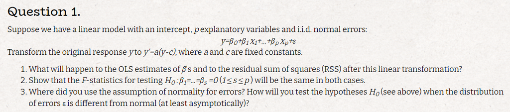

## a

$$y' = a(y-c)\\
\hat\beta' = (X^tX)^{-1} X^ty' = (X^tX)^{-1} X^t(a(y-c)) = a\hat\beta - ac((X^tX)^{-1} X^t)$$

## b

$$\textrm{we saw in class that: } RSS = \varepsilon^t(I-H)\varepsilon \sim \sigma^2\chi_{n-p}^2\\
\textrm{and also: } \varepsilon^tH\varepsilon + \varepsilon^t(I-H)\varepsilon = \varepsilon^t\varepsilon \sim \chi_n^2\textrm { and both are independent} \\
H\varepsilon = X(\hat\beta'-\beta) \Rightarrow \varepsilon^tH\varepsilon = (\hat\beta'-\beta)^tX^tX(\hat\beta'-\beta) \sim \sigma^2\chi_p^2\\
\textrm{thus we get: } \frac{(\hat\beta'-\beta)^tX^tX(\hat\beta'-\beta)}{\sigma^2p} / \frac{RSS}{\sigma^2(n-p)} =
\frac{(\hat\beta'-\beta)^tX^tX(\hat\beta'-\beta) }{RSS}\frac{n-p}{p} \sim\frac{\chi_{p}/p}{\chi_{n-p}/(n-p)} = F_{p,n-p}$$

## c

i used the normality for the distribution of $\varepsilon^t(I-H)\varepsilon$ and $\varepsilon^tH\varepsilon$ if the errors are not distributed normally we can try and use a transformation as to make them normal and them use an F test

# Q.2

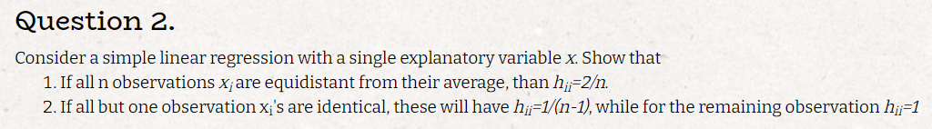

**1**

$$y = ax +b +\varepsilon\\
x_i = x_j\quad \forall i,j\\
h_{ii} = \frac{1}{n} + \frac{(x_i - \bar{x})^2}{\sum_{i=1}^n(x_j-\bar{x})^2}\\
x_i-\bar{x} = d \Rightarrow h_{ii} = \frac{1}{n} + \frac{d^2}{nd^2} = \frac{2}{n}$$

**2**

*w.l.o.g we can assume i = 1 is the different x*

$$x_j = w \quad \forall j>1\\
\bar{x} = \frac{x_1}{n} + \frac{(n-1)}{n}w\\
x_1 -\bar{x} = x_1 - \frac{x_1}{n} - \frac{(n-1)}{n}w = \frac{(n-1)(w-x_1)}{n}\\
x_j -\bar{x} = w - \frac{x_1}{n} - \frac{(n-1)}{n}w = \frac{(w-x_1)}{n}\\
\sum_{j=1}^n(x_j -\bar{x})^2 = (x_1 -\bar{x})^2 + (n-1)(w -\bar{x})^2 = (\frac{(n-1)(w-x_1)}{n})^2 + (n-1)\frac{(w-x_1)^2}{n^2} = \frac{[(n-1)^2-(n-1)](w-x_1)^2}{n^2} = \frac{(n-1)(w-x_1)^2}{n}\\
h_{11} = \frac{1}{n} + \frac{(x_1 -\bar{x})^2}{\sum_{j=1}^n(x_j -\bar{x})^2} = \frac{1}{n} + \frac{n-1}{n} = 1\\
h_{jj} = \frac{1}{n} + \frac{(x_j -\bar{x})^2}{\sum_{k=1}^n(x_k -\bar{x})^2} = \frac{1}{n} + \frac{(\frac{(w-x_1)}{n})^2}{\frac{(n-1)(w-x_1)^2}{n}} =\frac{1}{n} + \frac{1}{n(n-1)} = \frac{1}{n-1}$$

# Q.3

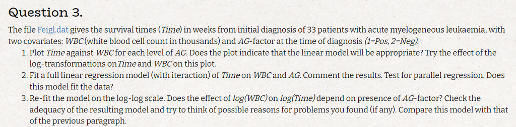

## a

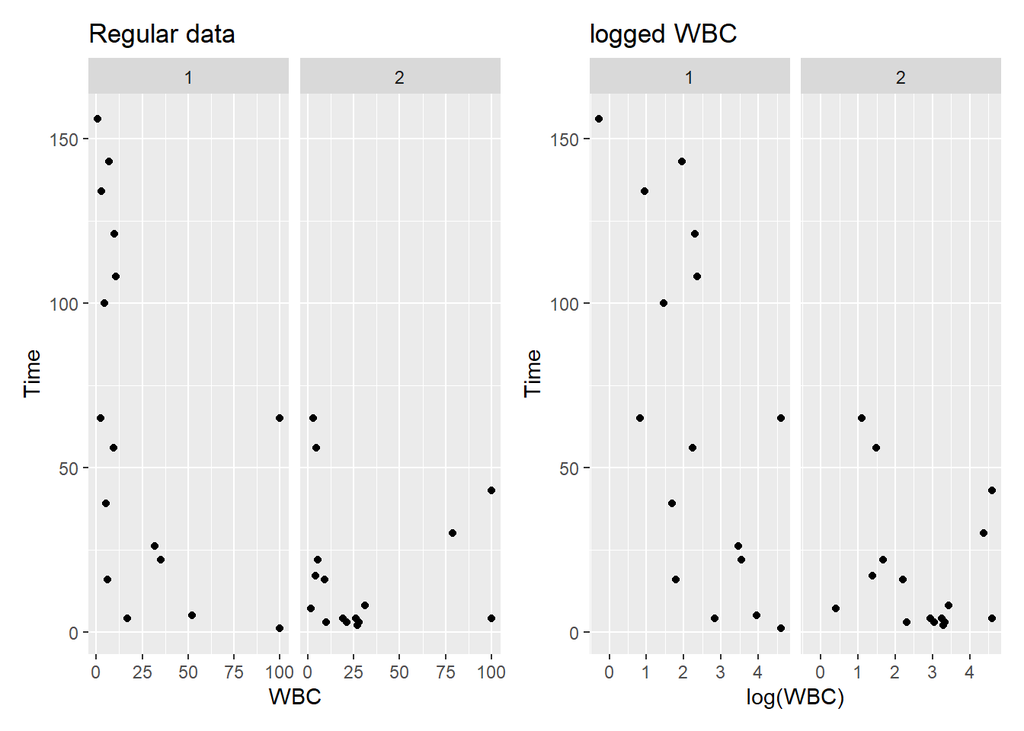

```r
tbl <- as_tibble(read.table("Feigl.dat"))
colnames(tbl) <- c("Time","WBC","AG")
tbl <- tbl %>%
  mutate(AG = as.factor(AG))
g_reg <- ggplot(tbl,aes(WBC,Time))+
  geom_point()+
  facet_wrap(tbl$AG)+
  ggtitle("Regular data")
g_log <- ggplot(tbl,aes(log(WBC),Time))+
  geom_point()+
  facet_wrap(tbl$AG)+
  ggtitle("logged WBC")
g_reg + g_log
```

## b

```r
model <- lm(Time~WBC + AG + WBC:AG,data = tbl)
summary(model)
```

```
##
## Call:
## lm(formula = Time ~ WBC + AG + WBC:AG, data = tbl)
##
## Residuals:
##     Min      1Q  Median      3Q     Max
## -68.113 -15.922  -9.949  24.593  70.910
##
## Coefficients:
##             Estimate Std. Error t value Pr(>|t|)
## (Intercept)  85.6887    11.6336   7.366 4.09e-08 ***
## WBC          -0.7986     0.2539  -3.145 0.003816 **
## AG2         -67.9454    17.0735  -3.980 0.000423 ***
## WBC:AG2       0.8052     0.3828   2.104 0.044206 *
## ---
## Signif. codes:  0 '***' 0.001 '**' 0.01 '*' 0.05 '.' 0.1 ' ' 1
##
## Residual standard error: 37.07 on 29 degrees of freedom
## Multiple R-squared:  0.429,  Adjusted R-squared:  0.3699
## F-statistic: 7.262 on 3 and 29 DF,  p-value: 0.00089
```

we can see that at least one of the covariates is significant according to the pvalue,lets check the interaction with a nested model anova:

```r
model_wo_interaction <- lm(Time~WBC + AG,data = tbl)
anova(model_wo_interaction,model)
```

```
## Analysis of Variance Table
##
## Model 1: Time ~ WBC + AG
## Model 2: Time ~ WBC + AG + WBC:AG
##   Res.Df   RSS Df Sum of Sq     F  Pr(>F)
## 1     30 45937
## 2     29 39856  1    6081.4 4.425 0.04421 *
## ---
## Signif. codes:  0 '***' 0.001 '**' 0.01 '*' 0.05 '.' 0.1 ' ' 1
```

we can see that the interaction is significant therefore the lines are not parallel, but the low R squered suggests that the model does not fit the data well.

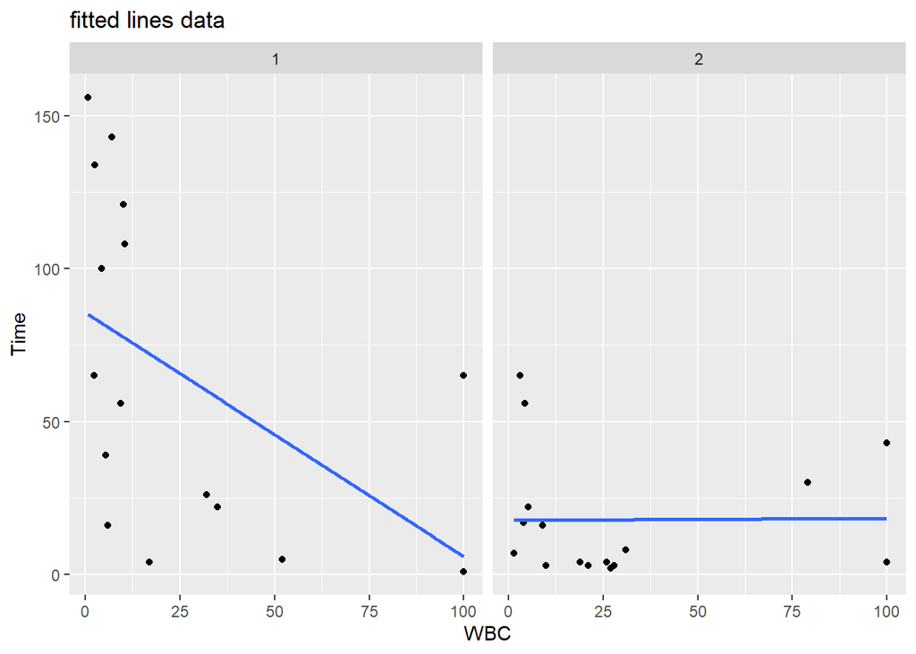

```r
pred = data.frame(Time_pred = predict(model,tbl))
ggplot(tbl,aes(WBC,Time))+
  geom_point()+
  facet_wrap(tbl$AG)+
  geom_smooth(method = "lm",formula = y~x,se = FALSE)+
  ggtitle("fitted lines data")
```

we can see from the plots that the line does not fit the data very well

## c

```r
log_tbl <- tbl %>%
  mutate(across(c(Time,WBC),log))
log_log_model <- lm(Time~WBC + AG + WBC:AG,data = log_tbl)
summary(log_log_model)
```

```
##
## Call:
## lm(formula = Time ~ WBC + AG + WBC:AG, data = log_tbl)
##
## Residuals:
##     Min      1Q  Median      3Q     Max
## -1.7221 -0.8597 -0.0164  0.6670  2.5151
##
## Coefficients:
##             Estimate Std. Error t value Pr(>|t|)
## (Intercept)   5.4254     0.6027   9.002 6.78e-10 ***
## WBC          -0.8178     0.2090  -3.914 0.000505 ***
## AG2          -2.5248     0.9445  -2.673 0.012208 *
## WBC:AG2       0.5834     0.3212   1.817 0.079640 .
## ---
## Signif. codes:  0 '***' 0.001 '**' 0.01 '*' 0.05 '.' 0.1 ' ' 1
##
## Residual standard error: 1.203 on 29 degrees of freedom
## Multiple R-squared:  0.4433, Adjusted R-squared:  0.3857
## F-statistic: 7.697 on 3 and 29 DF,  p-value: 0.0006249
```

our pvalue is lower and out R squared is higher which suggestes that the model better fits the data, lets also see it visually

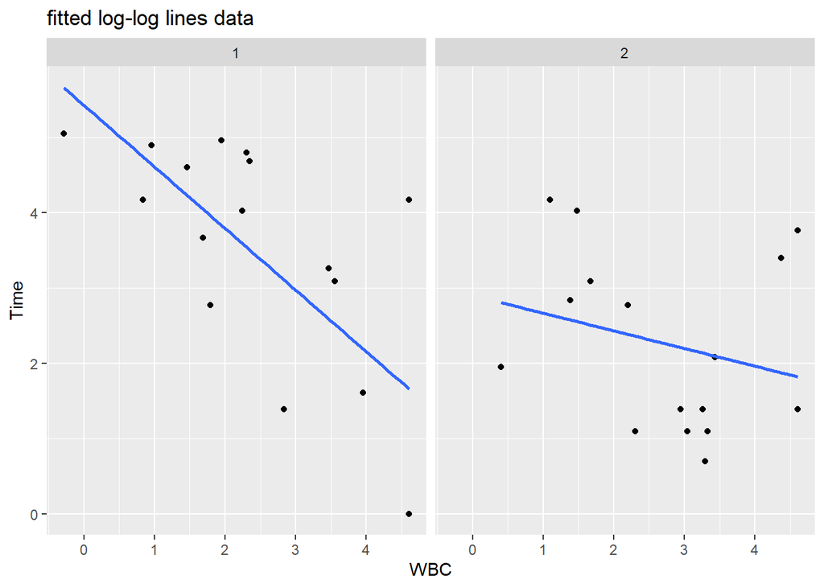

```r
log_pred = data.frame(Time_pred = predict(log_log_model,log_tbl))
ggplot(log_tbl,aes(WBC,Time))+
  geom_point()+
  facet_wrap(log_tbl$AG)+
  geom_smooth(method = "lm",formula = y~x,se = FALSE)+
  ggtitle("fitted log-log lines data")
```

fit looks better in both groups

```r
log_log_model_wo_interaction <- lm(Time~WBC + AG,data = log_tbl)
summary(log_log_model_wo_interaction)
```

```
##
## Call:
## lm(formula = Time ~ WBC + AG, data = log_tbl)
##
## Residuals:
##     Min      1Q  Median      3Q     Max
## -2.1734 -0.9372  0.2012  0.6411  2.5761
##
## Coefficients:
##             Estimate Std. Error t value Pr(>|t|)
## (Intercept)   4.8022     0.5142   9.340 2.19e-10 ***
## WBC          -0.5709     0.1647  -3.467  0.00161 **
## AG2          -0.9883     0.4361  -2.266  0.03081 *
## ---
## Signif. codes:  0 '***' 0.001 '**' 0.01 '*' 0.05 '.' 0.1 ' ' 1
##
## Residual standard error: 1.249 on 30 degrees of freedom
## Multiple R-squared:  0.3799, Adjusted R-squared:  0.3386
## F-statistic: 9.191 on 2 and 30 DF,  p-value: 0.00077
```

```r
anova(log_log_model_wo_interaction,log_log_model)
```

```
## Analysis of Variance Table
##
## Model 1: Time ~ WBC + AG
## Model 2: Time ~ WBC + AG + WBC:AG
##   Res.Df    RSS Df Sum of Sq      F  Pr(>F)
## 1     30 46.778
## 2     29 41.999  1    4.7789 3.2998 0.07964 .
## ---
## Signif. codes:  0 '***' 0.001 '**' 0.01 '*' 0.05 '.' 0.1 ' ' 1
```

the interaction no longer matters, we would expect that the interaction relevence to the model will stay the same, it could be that the not so normal errors in the regular model will cause this problem, lets comapre the qqplots and see how the non interaction model fits all the data

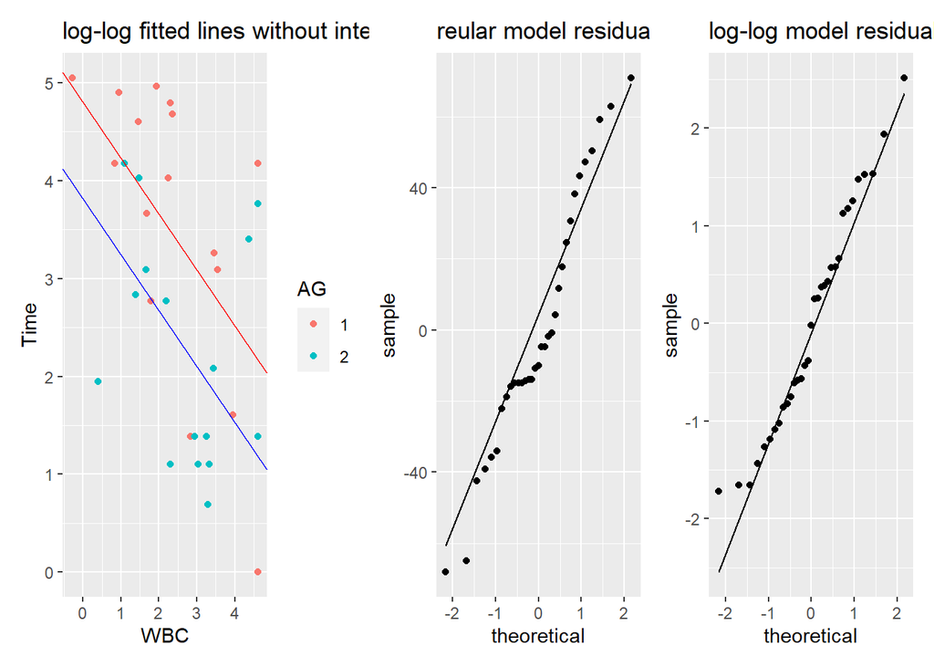

```r
coef_log_log_wo_interaction = log_log_model_wo_interaction$coefficients
slope = coef_log_log_wo_interaction[2]
inter_a = coef_log_log_wo_interaction[1]
inter_b = inter_a + coef_log_log_wo_interaction[3]
g3 <- ggplot(log_tbl,aes(WBC,Time))+
  geom_point(aes(color = AG))+
  geom_abline(slope = slope,intercept = inter_a,color = "red")+
  geom_abline(slope = slope,intercept = inter_b,color = "blue")+
  ggtitle("log-log fitted lines without interaction")

g4 <- ggplot(tibble(res = model$residuals),aes(sample = res)) +
  stat_qq()+
  stat_qq_line()+
  ggtitle("reular model residual qq-plot")
g5 <- ggplot(tibble(res = log_log_model$residuals),aes(sample = res)) +
  stat_qq()+
  stat_qq_line()+
  ggtitle("log-log model residual qq-plot")
g3 + g4+g5
```

# Q.4

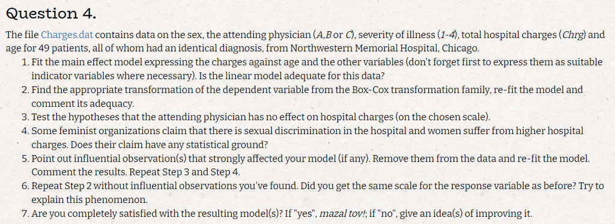

# a

```r
charges <- as_tibble(read.table("Charges.dat"))
colnames(charges) <- c("sex","physician","severity","Chrg","age")
charges <- charges %>%
  mutate(across(c(sex,physician,severity),as.factor))
lm_model <- lm(Chrg~.,data = charges)
summary(lm_model)
```

```
##
## Call:
## lm(formula = Chrg ~ ., data = charges)
##
## Residuals:
##    Min     1Q Median     3Q    Max
##  -7935  -2748   -785   1681  33225
##
## Coefficients:
##             Estimate Std. Error t value Pr(>|t|)
## (Intercept) -1742.54    4793.36  -0.364 0.718075
## sexM         -979.08    2133.96  -0.459 0.648796
## physicianB   1530.12    2368.62   0.646 0.521882
## physicianC   5332.34    2520.54   2.116 0.040503 *
## severity2    3613.57    2662.63   1.357 0.182161
## severity3   11703.53    2931.03   3.993 0.000264 ***
## severity4   18626.57    3315.32   5.618 1.51e-06 ***
## age           127.09      69.03   1.841 0.072859 .
## ---
## Signif. codes:  0 '***' 0.001 '**' 0.01 '*' 0.05 '.' 0.1 ' ' 1
##
## Residual standard error: 6464 on 41 degrees of freedom
## Multiple R-squared:  0.6779, Adjusted R-squared:  0.6229
## F-statistic: 12.33 on 7 and 41 DF,  p-value: 2.302e-08
```

the R squared of 0.6779 suggests that the model fits the data ok but not good enough

# b

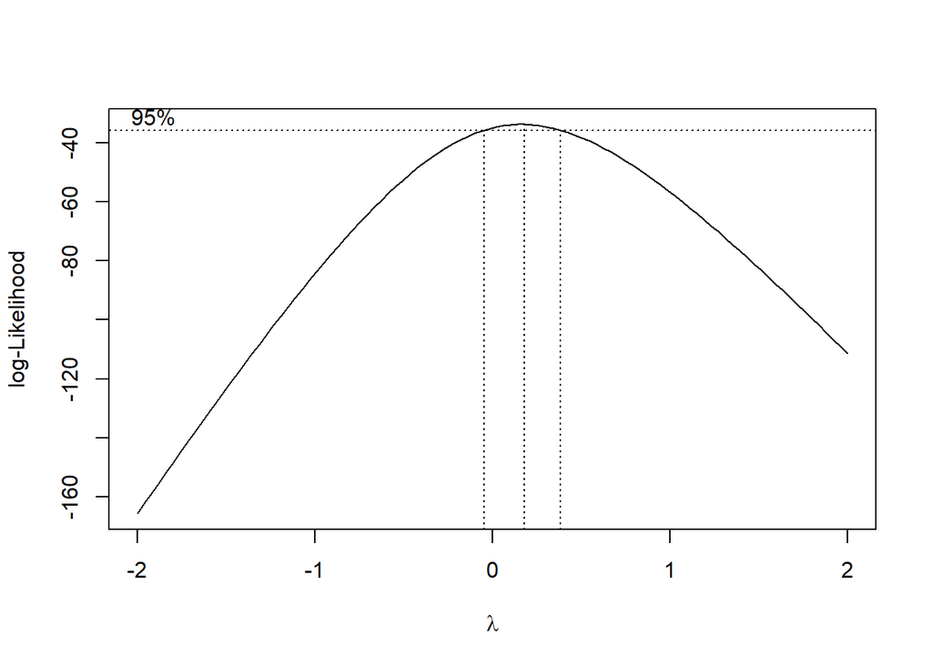

```r
boxcox(lm_model)
```

we can see that $\lambda = 0$ is at the interval so i will use the ln transformation

```r
log_model <- lm(log(Chrg)~.,data = charges)
summary(log_model)
```

```
##
## Call:
## lm(formula = log(Chrg) ~ ., data = charges)
##
## Residuals:
##      Min       1Q   Median       3Q      Max
## -0.54602 -0.17094 -0.06013  0.11014  0.83567
##
## Coefficients:
##             Estimate Std. Error t value Pr(>|t|)
## (Intercept)  7.38832    0.23609  31.295  < 2e-16 ***
## sexM         0.05206    0.10511   0.495  0.62300
## physicianB   0.05961    0.11666   0.511  0.61213
## physicianC   0.34108    0.12415   2.747  0.00889 **
## severity2    0.45439    0.13114   3.465  0.00126 **
## severity3    0.83116    0.14436   5.757 9.57e-07 ***
## severity4    1.04479    0.16329   6.398 1.17e-07 ***
## age          0.02062    0.00340   6.065 3.50e-07 ***
## ---
## Signif. codes:  0 '***' 0.001 '**' 0.01 '*' 0.05 '.' 0.1 ' ' 1
##
## Residual standard error: 0.3184 on 41 degrees of freedom
## Multiple R-squared:  0.8398, Adjusted R-squared:  0.8124
## F-statistic:  30.7 on 7 and 41 DF,  p-value: 2.301e-14
```

we got R-squared: 0.8398 that’s much better then out previous model

# c

```r
log_no_phys <- lm(log(Chrg)~.,data = dplyr::select(charges,-physician))
anova(log_no_phys,log_model)
```

```
## Analysis of Variance Table
##
## Model 1: log(Chrg) ~ sex + severity + age
## Model 2: log(Chrg) ~ sex + physician + severity + age
##   Res.Df    RSS Df Sum of Sq      F  Pr(>F)
## 1     43 5.0335
## 2     41 4.1564  2   0.87716 4.3263 0.01974 *
## ---
## Signif. codes:  0 '***' 0.001 '**' 0.01 '*' 0.05 '.' 0.1 ' ' 1
```

we can reject the null at 95% confidence: thus conclude that physician has an effect on hospital charges

# d

lets see if sex has an effect on hospital charges

```r
log_no_sex <- lm(log(Chrg)~.,data = dplyr::select(charges,-sex))
anova(log_no_sex,log_model)
```

```
## Analysis of Variance Table
##
## Model 1: log(Chrg) ~ physician + severity + age
## Model 2: log(Chrg) ~ sex + physician + severity + age
##   Res.Df    RSS Df Sum of Sq      F Pr(>F)
## 1     42 4.1812
## 2     41 4.1564  1  0.024875 0.2454  0.623
```

we can not reject the null at 95% confidence: thus we can not conclude that sex effect hospital charges

# e

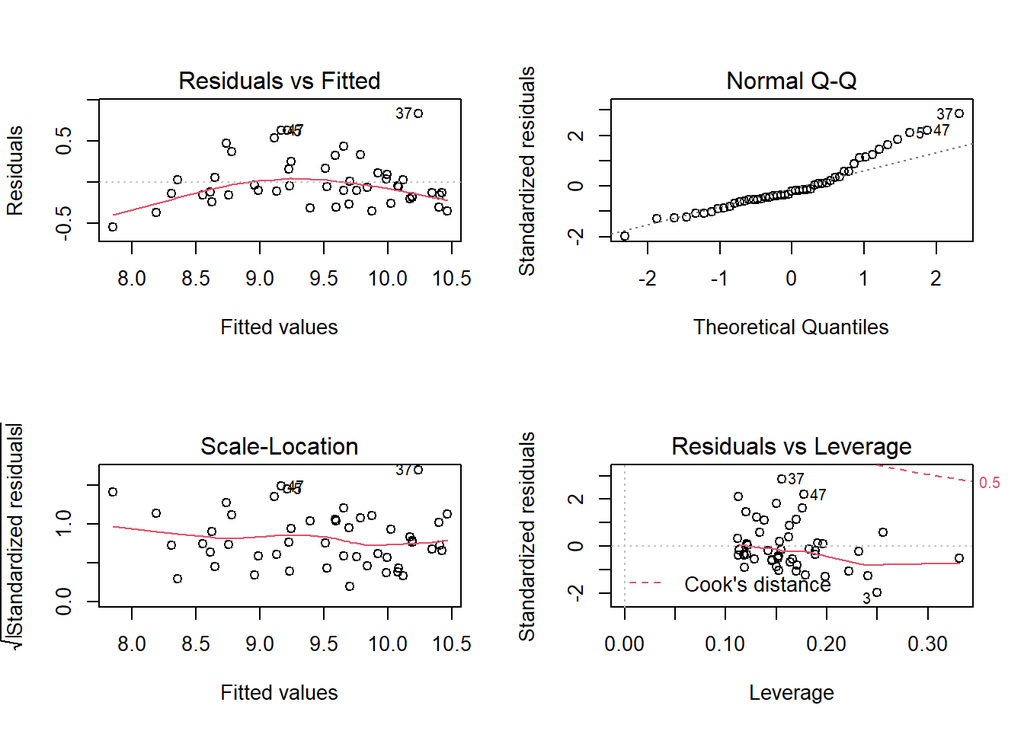

```r
par(mfrow = c(2,2))
plot(log_model)
```

```r
influential <- c(3,37,47)
glue("influential observations based on plots are: " ,glue_collapse(influential,sep=", "))
```

```
## influential observations based on plots are: 3, 37, 47
```

```r
re_charge <- charges[-influential,]
re_log_model <- lm(log(Chrg)~.,data = re_charge)
re_log_no_phys <- lm(log(Chrg)~.,data = dplyr::select(re_charge,-physician))
anova(re_log_no_phys,re_log_model)
```

```
## Analysis of Variance Table
##
## Model 1: log(Chrg) ~ sex + severity + age
## Model 2: log(Chrg) ~ sex + physician + severity + age
##   Res.Df    RSS Df Sum of Sq      F  Pr(>F)
## 1     40 2.7825
## 2     38 2.4144  2   0.36807 2.8964 0.06749 .
## ---
## Signif. codes:  0 '***' 0.001 '**' 0.01 '*' 0.05 '.' 0.1 ' ' 1
```

```r
re_log_no_sex <- lm(log(Chrg)~.,data = dplyr::select(re_charge,-sex))
anova(re_log_no_sex,re_log_model)
```

```
## Analysis of Variance Table
##
## Model 1: log(Chrg) ~ physician + severity + age
## Model 2: log(Chrg) ~ sex + physician + severity + age
##   Res.Df    RSS Df Sum of Sq      F Pr(>F)
## 1     39 2.4168
## 2     38 2.4144  1  0.002398 0.0377  0.847
```

we can see that now we do not reject the null hypotheses for physician meaning it does not effect charges and we still don’t reject the null for sex.

# f

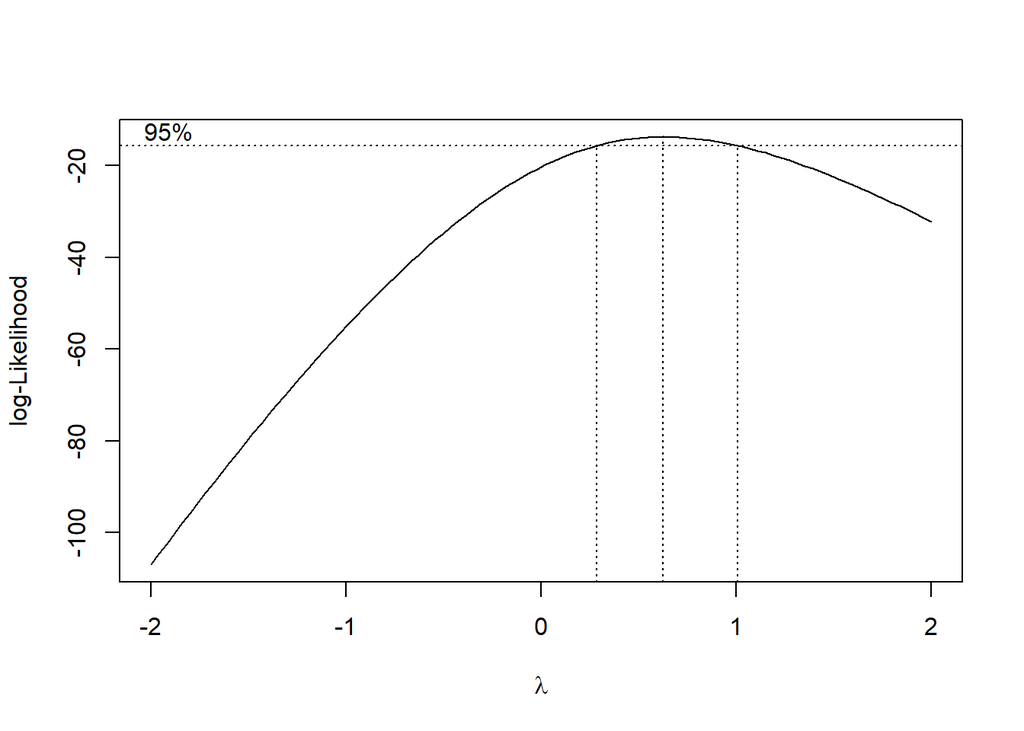

```r
boxcox(lm(Chrg~.,data = re_charge))
```

the interval for $\lambda$ moved. an explanation to this phenomenon can be that removing influential observations effects the likelihood function thus our $\lambda$ changes.

# g

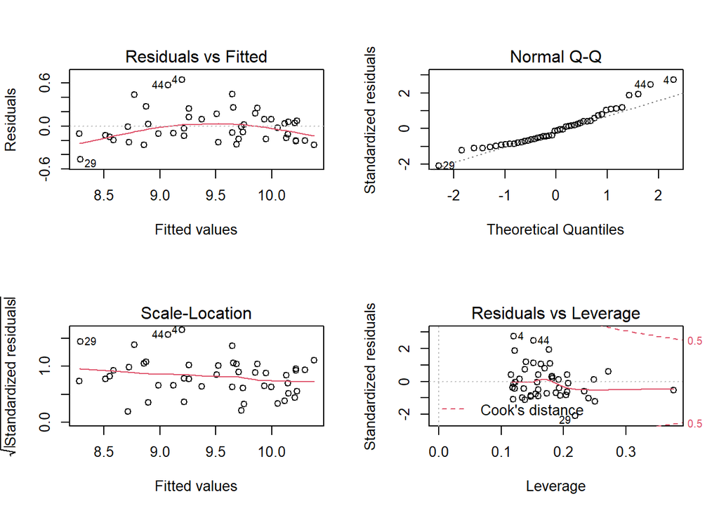

```r
par(mfrow = c(2,2))
plot(re_log_model)
```

```r
summary(re_log_model)
```

```
##
## Call:
## lm(formula = log(Chrg) ~ ., data = re_charge)
##
## Residuals:
##      Min       1Q   Median       3Q      Max
## -0.46501 -0.17466 -0.02768  0.09462  0.64541
##
## Coefficients:
##             Estimate Std. Error t value Pr(>|t|)
## (Intercept) 7.532956   0.203186  37.074  < 2e-16 ***
## sexM        0.016434   0.084594   0.194  0.84700
## physicianB  0.125850   0.094156   1.337  0.18929
## physicianC  0.241554   0.100807   2.396  0.02159 *
## severity2   0.340187   0.107810   3.155  0.00313 **
## severity3   0.798395   0.114930   6.947 2.90e-08 ***
## severity4   0.901634   0.134296   6.714 6.01e-08 ***
## age         0.019377   0.002943   6.585 9.01e-08 ***
## ---
## Signif. codes:  0 '***' 0.001 '**' 0.01 '*' 0.05 '.' 0.1 ' ' 1
##
## Residual standard error: 0.2521 on 38 degrees of freedom
## Multiple R-squared:   0.87,  Adjusted R-squared:  0.846
## F-statistic: 36.33 on 7 and 38 DF,  p-value: 6.207e-15
```

i think we can do better with the model, maybe try several lambdas in the interval and get a more suitable transformation (we can see that our log transformation could improve based on the qqplot) or maybe removing non significant covariants